# s670-HW4

Ruchik Rohit Dama

10/10/2021

#### Reading the Files.

```r
df_ratings=read_tsv("title_ratings.tsv", na = "\\N", quote = '')
df_basics=read_tsv("title_basics.tsv", na = "\\N", quote = '')
head(df_basics)
```

```
## # A tibble: 6 x 9
##   tconst    titleType primaryTitle     originalTitle   isAdult startYear endYear
##   <chr>     <chr>     <chr>            <chr>             <dbl>     <dbl>   <dbl>
## 1 tt0000001 short     Carmencita       Carmencita            0      1894      NA
## 2 tt0000002 short     Le clown et ses~ Le clown et se~       0      1892      NA
## 3 tt0000003 short     Pauvre Pierrot   Pauvre Pierrot        0      1892      NA
## 4 tt0000004 short     Un bon bock      Un bon bock           0      1892      NA
## 5 tt0000005 short     Blacksmith Scene Blacksmith Sce~       0      1893      NA
## 6 tt0000006 short     Chinese Opium D~ Chinese Opium ~       0      1894      NA
## # ... with 2 more variables: runtimeMinutes <dbl>, genres <chr>
```

#### Merging them into one dataframe

```r
df = merge(df_ratings, df_basics, by = "tconst")
```

```r
summary(df)
```

```
##     tconst          averageRating       numVotes          titleType
##  Length:1193568     Min.   : 1.000   Min.   :      5.0   Length:1193568
##  Class :character   1st Qu.: 6.200   1st Qu.:     11.0   Class :character
##  Mode  :character   Median : 7.100   Median :     24.0   Mode  :character
##                     Mean   : 6.926   Mean   :    976.3
##                     3rd Qu.: 7.900   3rd Qu.:     91.0
##                     Max.   :10.000   Max.   :2470290.0
##
##  primaryTitle       originalTitle         isAdult          startYear
##  Length:1193568     Length:1193568     Min.   :0.00000   Min.   :1874
##  Class :character   Class :character   1st Qu.:0.00000   1st Qu.:1994
##  Mode  :character   Mode  :character   Median :0.00000   Median :2008
##                                        Mean   :0.01656   Mean   :2001
##                                        3rd Qu.:0.00000   3rd Qu.:2015
##                                        Max.   :1.00000   Max.   :2021
##                                                          NA's   :192
##     endYear        runtimeMinutes       genres
##  Min.   :1933      Min.   :    0.0   Length:1193568
##  1st Qu.:1996      1st Qu.:   23.0   Class :character
##  Median :2009      Median :   45.0   Mode  :character
##  Mean   :2004      Mean   :   55.2
##  3rd Qu.:2016      3rd Qu.:   86.0
##  Max.   :2024      Max.   :51420.0
##  NA's   :1159344   NA's   :324988
```

#### Keeping only the data of movies.

```r
df=df[which(df$titleType=="movie"),]
```

#### Keeping only columns that are going to be used.

```r
df<-df[c('startYear','runtimeMinutes','averageRating','numVotes')]
head(df)
```

```
##     startYear runtimeMinutes averageRating numVotes
## 341      1905            100           4.5       14
## 375      1906             70           6.1      698
## 384      1907             90           5.2       16
## 398      1907             NA           4.5       23
## 406      1908             NA           3.8       23
## 436      1908             NA           4.9       19
```

```r
#df=na.omit(df)
```

#### Droppping Null Values.

```r
print('before dropping the null values')
```

```
## [1] "before dropping the null values"
```

```r
dim(df)
```

```
## [1] 269523      4
```

```r
df<-na.omit(df)
dim(df)
```

```
## [1] 242159      4
```

### 1. Fit a model to predict a movie’s IMDB rating (variableaverageRating) by year (startYear)and length (runtimeMinutes.) You will have to make a number of modeling choices:

#### (a) Do you need any transformations?

#### I tried multiple transformations. I used logarithmic transformations, and square transformations, but there was not any difference in the results so, I did not perform any transformations on the data.

#### Filtering out the tail values because there are outliers for the runtimeMinutes. Usually, movies are in the range of 50 minutes to 200 minutes. So, I am dropping all movies with length lesser than 50 and greater than 200 minutes.

```r
df=subset(df,df$runtimeMinutes<200)
df=subset(df,df$runtimeMinutes>50)
dim(df)
```

```
## [1] 236895      4
```

#### Distributions of each variable

```r
#g1=ggplot(df,aes(x = startYear))+geom_density())+xlab('start year')+ylab('count')+ggtitle('Year distribution')
#g2=ggplot(df,aes(x = runtimeMinutes))+geom_density() + xlim(c(0,200))+xlab('runtime')+ylab('Count')+xlim(50,200)+ggtitle('runtime distribution')
#g3=ggplot(df,aes(x = averageRating))+geom_density()+xlab('averageRating')+ylab('count')+ggtitle('averageRating distribution')

#grid.arrange(g1,g2,g3, nrow=2)
```

```r
#ggplot(df,aes(x =startYear, y = averageRating))+geom_point()+geom_smooth(method="gam")+facet_wrap(~cut_number(runtimeMinutes,10))
```

```r
#ggplot(df,aes(x=runtimeMinutes,y=averageRating))+geom_point(alpha=0.5,size=0.3)+facet_wrap(~cut_width(df$startYear,10))+geom_smooth(method='gam',se=FALSE)+ggtitle('AverageRating vs RuntimeMinutes')+labs(subtitle = "Cut by #Years in Decades")
```

#### Linear Model(lm)

##### Without using weights.

```r
model_lm=lm(averageRating~startYear+runtimeMinutes,data=df)
summary(model_lm)
```

```
##
## Call:
## lm(formula = averageRating ~ startYear + runtimeMinutes, data = df)
##
## Residuals:
##     Min      1Q  Median      3Q     Max
## -5.3524 -0.7653  0.1279  0.8807  3.9786
##
## Coefficients:
##                 Estimate Std. Error t value Pr(>|t|)
## (Intercept)    4.8291402  0.2116782  22.814  < 2e-16 ***
## startYear      0.0005076  0.0001068   4.755 1.99e-06 ***
## runtimeMinutes 0.0030832  0.0001269  24.305  < 2e-16 ***
## ---
## Signif. codes:  0 '***' 0.001 '**' 0.01 '*' 0.05 '.' 0.1 ' ' 1
##
## Residual standard error: 1.305 on 236892 degrees of freedom
## Multiple R-squared:  0.002742,   Adjusted R-squared:  0.002734
## F-statistic: 325.7 on 2 and 236892 DF,  p-value: < 2.2e-16
```

##### With using weights.

```r
model_lmw=lm(averageRating~startYear+runtimeMinutes,weights=numVotes,data=df)
summary(model_lmw)
```

```
##
## Call:
## lm(formula = averageRating ~ startYear + runtimeMinutes, data = df,
##     weights = numVotes)
##
## Weighted Residuals:
##      Min       1Q   Median       3Q      Max
## -2220.14   -16.25    -4.97     2.17  2539.07
##
## Coefficients:
##                  Estimate Std. Error t value Pr(>|t|)
## (Intercept)     3.436e+01  2.373e-01   144.8   <2e-16 ***
## startYear      -1.480e-02  1.188e-04  -124.6   <2e-16 ***
## runtimeMinutes  1.997e-02  8.447e-05   236.4   <2e-16 ***
## ---
## Signif. codes:  0 '***' 0.001 '**' 0.01 '*' 0.05 '.' 0.1 ' ' 1
##
## Residual standard error: 57.68 on 236892 degrees of freedom
## Multiple R-squared:  0.2211, Adjusted R-squared:  0.2211
## F-statistic: 3.362e+04 on 2 and 236892 DF,  p-value: < 2.2e-16
```

#### Generalized Additive Model(gam)

##### Without using weights.

```r
model_gam <- gam(averageRating~startYear+s(runtimeMinutes),data=df,method='REML')
summary(model_gam)
```

```
##
## Family: gaussian
## Link function: identity
##
## Formula:
## averageRating ~ startYear + s(runtimeMinutes)
##
## Parametric coefficients:
##              Estimate Std. Error t value Pr(>|t|)
## (Intercept) 4.3324525  0.2118220  20.453   <2e-16 ***
## startYear   0.0009019  0.0001063   8.488   <2e-16 ***
## ---
## Signif. codes:  0 '***' 0.001 '**' 0.01 '*' 0.05 '.' 0.1 ' ' 1
##
## Approximate significance of smooth terms:
##                     edf Ref.df   F p-value
## s(runtimeMinutes) 8.618  8.928 723  <2e-16 ***
## ---
## Signif. codes:  0 '***' 0.001 '**' 0.01 '*' 0.05 '.' 0.1 ' ' 1
##
## R-sq.(adj) =  0.0268   Deviance explained = 2.68%
## -REML = 3.9635e+05  Scale est. = 1.662     n = 236895
```

##### With using weights.

```r
model_gamw = gam(averageRating~startYear+s(runtimeMinutes),data=df,weights=numVotes,method='REML')
summary(model_gamw)
```

```
##
## Family: gaussian
## Link function: identity
##
## Formula:
## averageRating ~ startYear + s(runtimeMinutes)
##
## Parametric coefficients:
##               Estimate Std. Error t value Pr(>|t|)
## (Intercept) 37.0970083  0.2410579   153.9   <2e-16 ***
## startYear   -0.0152448  0.0001208  -126.2   <2e-16 ***
## ---
## Signif. codes:  0 '***' 0.001 '**' 0.01 '*' 0.05 '.' 0.1 ' ' 1
##
## Approximate significance of smooth terms:
##                     edf Ref.df    F p-value
## s(runtimeMinutes) 8.844  8.991 6503  <2e-16 ***
## ---
## Signif. codes:  0 '***' 0.001 '**' 0.01 '*' 0.05 '.' 0.1 ' ' 1
##
## R-sq.(adj) =  0.214   Deviance explained = 22.8%
## -REML = 7.3785e+05  Scale est. = 3297.4    n = 236895
```

```r
model_gam_df = data.frame(df,
                   .fitted = fitted.values(model_gamw),
                   .resid = residuals(model_gamw))
head(model_gam_df)
```

```
##     startYear runtimeMinutes averageRating numVotes  .fitted      .resid
## 341      1905            100           4.5       14 8.188612 -13.8015226
## 375      1906             70           6.1      698 7.584382 -39.2169020
## 384      1907             90           5.2       16 7.877431 -10.7097251
## 439      1908            120           5.3       65 8.618594 -26.7553642
## 740      1910             58           3.4       19 7.458129 -17.6889741
## 841      1911             51           7.7       12 7.418402   0.9754829
```

#### (d) Do you need to filter out or downweight tail values to prevent the fit from being dominated by outliers?

#### SInce, the outliers do not contribute in the data, we Filter out the tail values for the runtimeMinutes. Usually, movies are in the range of 50 minutes to 200 minutes. So, I am dropping all movies with length lesser than 50 and greater than 200 minutes.

#### (e) Should you weight by number of votes?

#### After using both weighted and non-weightd lm and gam, I can say that the weighted gam model showed better result than non-weighted gam model. the non-weighted gam model had a R-square rating of 0.0268 and deviance explained was 2.68% whereas the weighed gam model had R square value of 0.214 and deviance explained 22.8%.

```r
grid_df=expand.grid(runtimeMinutes=50:200,startYear=1896:2021)
grid_predict=predict(model_gamw,newdata=grid_df)
predict_grid_df=data.frame(grid_df,avgRating=as.vector(grid_predict))
```

```r
head(predict_grid_df)
```

```
##   runtimeMinutes startYear avgRating
## 1             50      1896  7.643675
## 2             51      1896  7.647074
## 3             52      1896  7.650474
## 4             53      1896  7.653881
## 5             54      1896  7.657304
## 6             55      1896  7.660760
```

### 2. Draw ONE set of faceted plots to display the model — either condition on year or length,whichever seems to you to be more interesting. Choose a sensible number of panels. Briefly describe what this set of plots shows you.

[figure not shown]

```r
ggplot(predict_grid_df, aes(x = runtimeMinutes, y=avgRating)) + geom_point()+
geom_smooth(method='gam')+
facet_wrap(~cut_width(predict_grid_df$startYear,10))+
ggtitle('Relation Between Average Rating and Length of the movies')+
labs(subtitle = "Cut by Years in Decades",x="Average Rating",y="Length of the movies")
```

### 3. Draw a raster-and-contour plot (or other “3D” plot of your choice) to further display yourmodel. The plot should show predictions for the majority of movie years and lengths (youdon’t have to show outliers.) Briefly describe what, if anything, this plot shows you that yourplot for question 2 didn’t.

#### From the contour plots, we cans see that ratings increase as runtime increases. For Example, when the runtime is near 50, the ratings are near 6 or 7 and as runtime reaches 100, we get some movies with ratings near 8 and as the runtime increases to 150-200 we get moves with ratings 9 and above. We can also see the there dependency on the year column. We can see that the as the year increases ,the ratings also change.The shorter movies , the older movies have slightly higher rating than the recent movies. Even for the longer movies, the older movies have higher rating than recent movies. For Example, the shorter movies of 50 mintues, the older movies have ratings of 7 whereas the recent movies have rating of 6. SImilarly, for longer movies of 150-200 minutes, the older movies have higher ratings of 9 and above but the recent movies have there ratings till 8. In the facet plots we couldn’t see how does the year affects the ratings of the movies, but in the contour plots we can see the affect of year on the ratings.

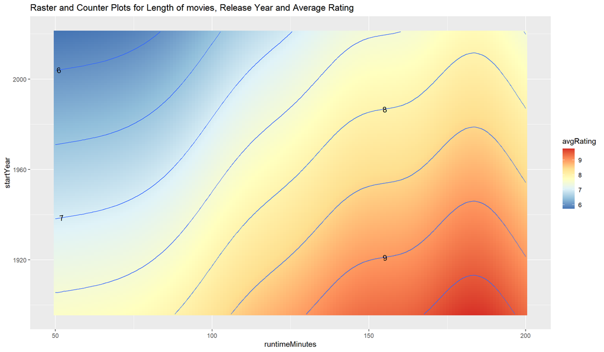

```r
ggplot(predict_grid_df,aes(x = runtimeMinutes, y = startYear, z =avgRating,fill=avgRating))+geom_raster()+
  scale_fill_distiller(palette = "RdYlBu")+
  geom_contour()+
  geom_text_contour()+
  ggtitle('Raster and Counter Plots for Length of movies, Release Year and Average Rating')
```